# R Notebook

# DDG2P: The relation between the number of phenotypes and DDD categories of mutation consequences

## 1. Load DDG2P dataset

```r
library(tidyverse)
library(ggplot2)
library(dplyr)
library(ggrepel)

DDG2P_hpo <- read.table("table.hpo_obo_20190924.txt", sep='\t', header = T)
DDG2P_pLI <- read.delim("DDG2P_24_9_2019.with_pLI.txt")
```

## 2. Visualization

I separated the phenotypes in each disease and changed its form into an easier form for calculation.

```r
ddg2p <- DDG2P_pLI %>%
  separate_rows(phenotypes, sep = ';') %>%
  na.omit()
ddg2p
```

|  | gene.symbol | gene.mim | disease.name | disease.mim | DDD.category | allelic.requirement | mutation.consequence | phenotypes | organ.specificity.list | pmids | panel | prev.symbols | hgnc.id | gene.disease.pair.entry.date | pLI | pRec | pNull |
| --- | --- | --- | --- | --- | --- | --- | --- | --- | --- | --- | --- | --- | --- | --- | --- | --- | --- |
| 35 | ABCB11 | 603201 | ABCB11-RELATED INTRAHEPATIC CHOLESTASIS | 601847 | confirmed | biallelic | loss of function | HP:0003155 | GI tract | 10579978;9806540;16039748 | DD | BSEP;PFIC2 | 42 | 2015-07-22 16:14:39 | 2.188495e-10 | 9.982639e-01 | 1.736073e-03 |
| 36 | ABCB11 | 603201 | ABCB11-RELATED INTRAHEPATIC CHOLESTASIS | 601847 | confirmed | biallelic | loss of function | HP:0004322 | GI tract | 10579978;9806540;16039748 | DD | BSEP;PFIC2 | 42 | 2015-07-22 16:14:39 | 2.188495e-10 | 9.982639e-01 | 1.736073e-03 |
| 37 | ABCB11 | 603201 | ABCB11-RELATED INTRAHEPATIC CHOLESTASIS | 601847 | confirmed | biallelic | loss of function | HP:0003819 | GI tract | 10579978;9806540;16039748 | DD | BSEP;PFIC2 | 42 | 2015-07-22 16:14:39 | 2.188495e-10 | 9.982639e-01 | 1.736073e-03 |
| 38 | ABCB11 | 603201 | ABCB11-RELATED INTRAHEPATIC CHOLESTASIS | 601847 | confirmed | biallelic | loss of function | HP:0001508 | GI tract | 10579978;9806540;16039748 | DD | BSEP;PFIC2 | 42 | 2015-07-22 16:14:39 | 2.188495e-10 | 9.982639e-01 | 1.736073e-03 |
| 39 | ABCB11 | 603201 | ABCB11-RELATED INTRAHEPATIC CHOLESTASIS | 601847 | confirmed | biallelic | loss of function | HP:0002240 | GI tract | 10579978;9806540;16039748 | DD | BSEP;PFIC2 | 42 | 2015-07-22 16:14:39 | 2.188495e-10 | 9.982639e-01 | 1.736073e-03 |
| 40 | ABCB11 | 603201 | ABCB11-RELATED INTRAHEPATIC CHOLESTASIS | 601847 | confirmed | biallelic | loss of function | HP:0002908 | GI tract | 10579978;9806540;16039748 | DD | BSEP;PFIC2 | 42 | 2015-07-22 16:14:39 | 2.188495e-10 | 9.982639e-01 | 1.736073e-03 |
| 41 | ABCB11 | 603201 | ABCB11-RELATED INTRAHEPATIC CHOLESTASIS | 601847 | confirmed | biallelic | loss of function | HP:0001402 | GI tract | 10579978;9806540;16039748 | DD | BSEP;PFIC2 | 42 | 2015-07-22 16:14:39 | 2.188495e-10 | 9.982639e-01 | 1.736073e-03 |
| 42 | ABCB11 | 603201 | ABCB11-RELATED INTRAHEPATIC CHOLESTASIS | 601847 | confirmed | biallelic | loss of function | HP:0000989 | GI tract | 10579978;9806540;16039748 | DD | BSEP;PFIC2 | 42 | 2015-07-22 16:14:39 | 2.188495e-10 | 9.982639e-01 | 1.736073e-03 |
| 43 | ABCB11 | 603201 | ABCB11-RELATED INTRAHEPATIC CHOLESTASIS | 601847 | confirmed | biallelic | loss of function | HP:0000007 | GI tract | 10579978;9806540;16039748 | DD | BSEP;PFIC2 | 42 | 2015-07-22 16:14:39 | 2.188495e-10 | 9.982639e-01 | 1.736073e-03 |
| 44 | ABCB11 | 603201 | ABCB11-RELATED INTRAHEPATIC CHOLESTASIS | 601847 | confirmed | biallelic | loss of function | HP:0003593 | GI tract | 10579978;9806540;16039748 | DD | BSEP;PFIC2 | 42 | 2015-07-22 16:14:39 | 2.188495e-10 | 9.982639e-01 | 1.736073e-03 |

[output cut: 990 more lines]

```r
nphenotypes <- as.numeric(as.factor(gsub("HP:0", "", ddg2p$phenotypes)))
nphenotypes
```

```
   [1] 1458 1678 1650  751 1113 1365  722  530    3 1599  558
  [12]  724  980  717  864 1259  441    3  813  829 1771  852
  [23]   64    9 1061  175  642  925 1030  649 1007  160 1222
  [34] 1367 2009 1597  983    3  939 1059 2663  838 1488 2645
  [45]  926  811 1325 1454   10  752 1587  811  715  810  982
  [56] 1265 1881  751    3  638 1911  979  951  638  730 2687
  [67] 2687 1664  638 1974    2  790 1031  904  201 2275 2649
  [78] 1738  366 2650 2480 1407 2648 2474 1265  202  136  789
  [89]  279  622  819 2583 1995 1025    3  810 1192  194  348
 [100]  574 1325  264  257  984 1599    2 2116 2735  388  638
 [111]  149  382  406  947  211  385  731  405 2664  879 1265
 [122] 2573 2751  639 2681 1482  682 2069 1019  981 1014    3
 [133] 1140 1599  689 2672  259  675 1044  686 1610  647  350
 [144]  657  317  339    2 1015 1179  263  338  671 1578  644
 [155] 1611 1013  259  686  647  657 1268  248 1313 2445   64
```

[output cut: 77 more lines]

```r
ddg2p <- mutate(ddg2p, phenotypes = nphenotypes)
```

Then, I selected 3 columns out of the whole data to make it easier for me to analyze.

```r
ddg2p %>%
  select('DDD.category', 'mutation.consequence', 'phenotypes')
```

| DDD.category | mutation.consequence | phenotypes |
| --- | --- | --- |
| confirmed | loss of function | 1458 |
| confirmed | loss of function | 1678 |
| confirmed | loss of function | 1650 |
| confirmed | loss of function | 751 |
| confirmed | loss of function | 1113 |
| confirmed | loss of function | 1365 |
| confirmed | loss of function | 722 |
| confirmed | loss of function | 530 |
| confirmed | loss of function | 3 |
| confirmed | loss of function | 1599 |

[output cut: 990 more lines]

I used the function `group_by` to group the table into `DDD.category` and `mutation.consequence`. Then I counted the number of phenotypes for the grouped form.

```r
ddg2p %>%
  select('DDD.category', 'mutation.consequence', 'phenotypes') %>%
  group_by(DDD.category, mutation.consequence) %>%
  count(name = 'no.phenotype')
```

| DDD.category | mutation.consequence | no.phenotype |
| --- | --- | --- |
| both RD and IF | all missense/in frame | 14 |
| both RD and IF | loss of function | 62 |
| child IF | all missense/in frame | 19 |
| child IF | loss of function | 45 |
| confirmed | 5_prime or 3_prime UTR mutation | 5 |
| confirmed | activating | 752 |
| confirmed | all missense/in frame | 830 |
| confirmed | dominant negative | 353 |
| confirmed | gain of function | 48 |
| confirmed | increased gene dosage | 14 |

[output cut: 14 more lines]

I assigned the table to `b`.

```r
b <- ddg2p %>%
  select('DDD.category', 'mutation.consequence', 'phenotypes') %>%
  group_by(DDD.category, mutation.consequence) %>%
  count(name = 'no.phenotype')
b
```

| DDD.category | mutation.consequence | no.phenotype |
| --- | --- | --- |
| both RD and IF | all missense/in frame | 14 |
| both RD and IF | loss of function | 62 |
| child IF | all missense/in frame | 19 |
| child IF | loss of function | 45 |
| confirmed | 5_prime or 3_prime UTR mutation | 5 |
| confirmed | activating | 752 |
| confirmed | all missense/in frame | 830 |
| confirmed | dominant negative | 353 |
| confirmed | gain of function | 48 |
| confirmed | increased gene dosage | 14 |

[output cut: 14 more lines]

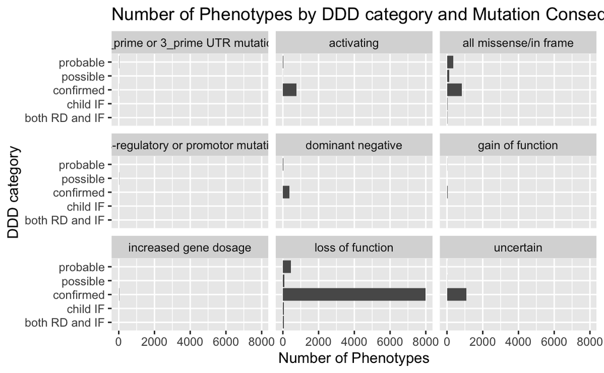

```r
b %>% ggplot(aes(DDD.category, no.phenotype)) +
  geom_bar(stat = "identity") +
  coord_flip() +
  facet_wrap(mutation.consequence~.) +
  labs(title = 'Number of Phenotypes by DDD category and Mutation Consequence' , x = 'DDD category', y = 'Number of Phenotypes')
```

## 3. Modification

plot 1

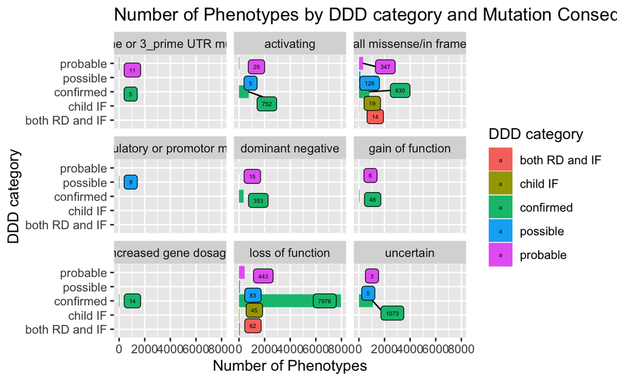

```r
b %>% ggplot(aes(DDD.category, no.phenotype, fill = DDD.category, label = no.phenotype)) +
  geom_bar(stat = "identity") +
  geom_label_repel(size = 1.5) +
  scale_fill_discrete(name = 'DDD category') +
  coord_flip() +
  facet_wrap(mutation.consequence~.) +
  labs(title = 'Number of Phenotypes by DDD category and Mutation Consequence' , x = 'DDD category', y = 'Number of Phenotypes')
```

- I have added the labels to each values to make sure the small values could still be shown it was there.
- It was still difficult to precisely identify all values just by using `geom_text`. So I have replaced it with `geom_label_repel` in order for it to be distinguished easily.
- To make an improvement on the opinion that the plot looks too simple in black and white, I have used the `fill =` function to present different colors for each DDD category.

plot 2

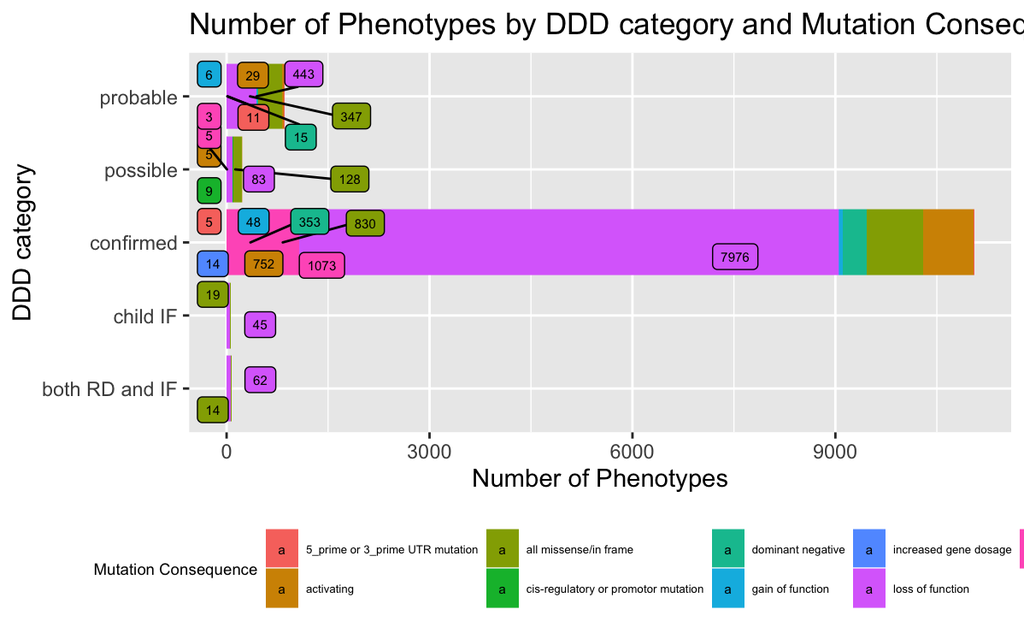

```r
b %>% ggplot(aes(DDD.category, no.phenotype, fill = mutation.consequence, label = no.phenotype)) +
  geom_bar(stat = "identity") +
  theme(legend.key.width = unit(0.5, 'cm'), legend.position = 'bottom', legend.text = element_text(size=5), legend.title = element_text(size=7))+
  geom_label_repel(size = 2) +
  scale_fill_discrete(name = 'Mutation Consequence') +
  coord_flip() +
  labs(title = 'Number of Phenotypes by DDD category and Mutation Consequence' , x = 'DDD category', y = 'Number of Phenotypes')
```

- One opinion said that it wasn’t nessesary to use `facet_wrap` for the plot. So I have changed the plot form into a barplot that is stacked with mutation consequences and sorted into DDD categories.
- The values for this plot were also very close to each other so I have used `geom_label_repel` to label numbers for each values.
- The legend was initially on the right side of the plot but I moved it to the bottom of the plot so that there were more space for the plot.